# Consumer Spending Analysis

Kate Ammirati

2026-10-27

## Project Objective

The objective of this project is to analyze average annual consumer expenditures across income groups in the United States from 2022 to 2024 using data from the Bureau of Labor Statistics Consumer Expenditure Survey. Using R, I will explore how spending varies by income level, identify changes in spending over time, and create visualizations to highlight key findings.

Source: https://www.bls.gov/cex/tables.htm

## Consumer Spending by Year

```
##   Year Spending
## 1 2022    72973
## 2 2023    77280
## 3 2024    78535
```

## Spending by Income Group

```
##            Series_ID Spending
## 1 CXUTOTALEXPLB0102M    35046
## 2 CXUTOTALEXPLB0103M    50054
## 3 CXUTOTALEXPLB0104M    66900
## 4 CXUTOTALEXPLB0101M    78535
## 5 CXUTOTALEXPLB0105M    89972
## 6 CXUTOTALEXPLB0106M   150342
```

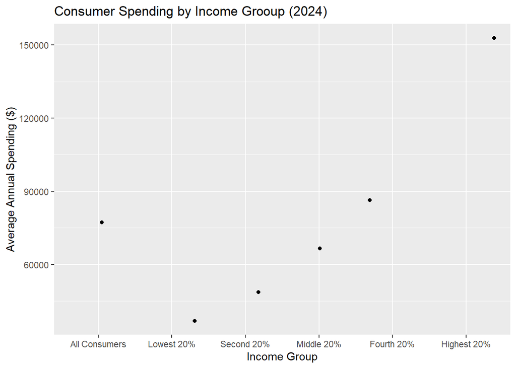

## Consumer Spending Trends (2022-2024)

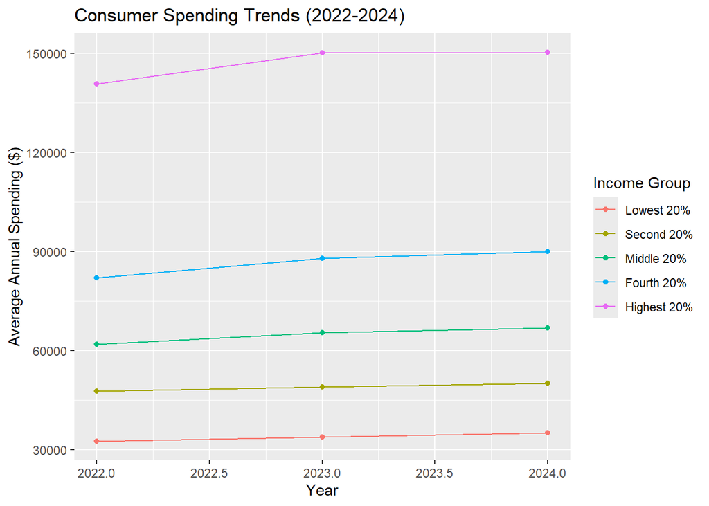

## Key Findings

Analysis of Consumer Expenditure Survey data from 2022 to 2024 highlights several patterns in household spending. - Average annual spending increased across all five income quintiles between 2022 and 2024. - Higher income households consistently reported greater annual expenditures than lower-income households. - In 2024, the highest-income quintile spent approximately $150,342 annually, compared to the $35,046 for the lowest-income quintile. - These findings show substantial differences in consumer spending across income groups.

**Conclusion:** Consumer spending is varied by income level, with higher-income households spending substantially more annually. While spending increased across all income groups during the period analyzed, these nominal increases do not necessarily prove increases in purchasing power.